# Analysis on Weight Lifting Exercises

Chamika Subashinie

October 28, 2017

## Background

Using devices such as Jawbone Up, Nike FuelBand, and Fitbit it is now possible to collect a large amount of data about personal activity relatively inexpensively. These type of devices are part of the quantified self movement - a group of enthusiasts who take measurements about themselves regularly to improve their health, to find patterns in their behavior, or because they are tech geeks. One thing that people regularly do is quantify how much of a particular activity they do, but they rarely quantify how well they do it. In this project, your goal will be to use data from accelerometers on the belt, forearm, arm, and dumbell of 6 participants. They were asked to perform barbell lifts correctly and incorrectly in 5 different ways. More information is available from the website here: http://groupware.les.inf.puc-rio.br/har (see the section on the Weight Lifting Exercise Dataset).

## Data

The training data: https://d396qusza40orc.cloudfront.net/predmachlearn/pml-training.csv

The test data: https://d396qusza40orc.cloudfront.net/predmachlearn/pml-testing.csv

The data for this project come from this source: http://web.archive.org/web/20161224072740/http:/groupware.les.inf.puc-rio.br/har

## Analysis

#### Load the data

```r
trainData <- read.csv(file.path("https://d396qusza40orc.cloudfront.net/predmachlearn/pml-training.csv"))
testData <- read.csv(file.path("https://d396qusza40orc.cloudfront.net/predmachlearn/pml-testing.csv"))
```

loading packages

```r
library(lattice)
library(caret)
library(randomForest)
library(ggplot2)
library(rpart)
library(rattle)
```

Training and testing data

```r
training <- subset(trainData, select = -c(X))
testing <- subset(testData, select = -c(X))
```

#### Clean the data

Remove the near zero variance predictors. They are not only non-informative, they are problematic to fit models.

```r
nzv <- nearZeroVar(training, saveMetrics = TRUE)
training <- training[,nzv$nzv==FALSE]
```

Remove all the variables with more than 75% NA

```r
rows <- dim(training)[1]
variables <- dim(training)[2]

cleanNA <- training
for(i in 1:variables){
        if( sum(is.na(training[,i]))/rows >= 0.75){
                for(j in 1:dim(cleanNA)[2]){
                        if(length( grep(names(training[i]), names(cleanNA)[j]))==1){
                                cleanNA <- cleanNA[,-j]
                        }
                }
        }
}

training <- cleanNA

predictors <- colnames(training[,-58])
testing <- testing[predictors]
```

Coerce the training and testing data into a same type and get the same class in all the variables.

```r
for (i in 1:dim(testing)[2] ) {
    for(j in 1:dim(training)[2]) {
        if( length( grep(names(training[i]), names(testing)[j]) ) == 1)  {
            class(testing[j]) <- class(training[i])
        }
    }
}

testing <- rbind(training[1, -58] , testing)
testing <- testing[-1,]
```

#### Partition data

partitioning data to train and test the model

```r
inTrain <- createDataPartition(training$classe, p=0.7, list=FALSE)
myTraining <- training[inTrain,]
myTesting <- training[-inTrain,]
```

#### Model fitting

1. Random Forest Method

```r
set.seed(333)
mod1 <- randomForest(classe ~ . , data=myTraining)
pred1 <- predict(mod1, myTesting)
accuracy1 <- confusionMatrix(pred1, myTesting$classe)$overall[1]
accuracy1
```

```
##  Accuracy
## 0.9989805
```

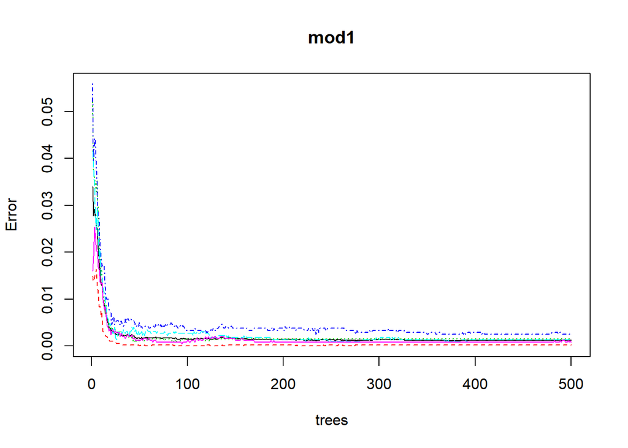

```r
plot(mod1)
```

2. Linear Discriminant Analysis

```r
set.seed(333)
mod2 <- train(classe~. , method="lda", data=myTraining)
pred2 <- predict(mod2, myTesting)
accuracy2 <- confusionMatrix(pred2, myTesting$classe)$overall[1]
accuracy2
```

```
##  Accuracy
## 0.8502974
```

3. Regression Trees

```r
set.seed(333)
mod3 <- rpart(classe~., data = myTraining, method = "class")
pred3 <- predict(mod3,myTesting, type="class")
accuracy3 <- confusionMatrix(pred3, myTesting$classe)$overall[1]
accuracy3
```

```
##  Accuracy
## 0.9009346
```

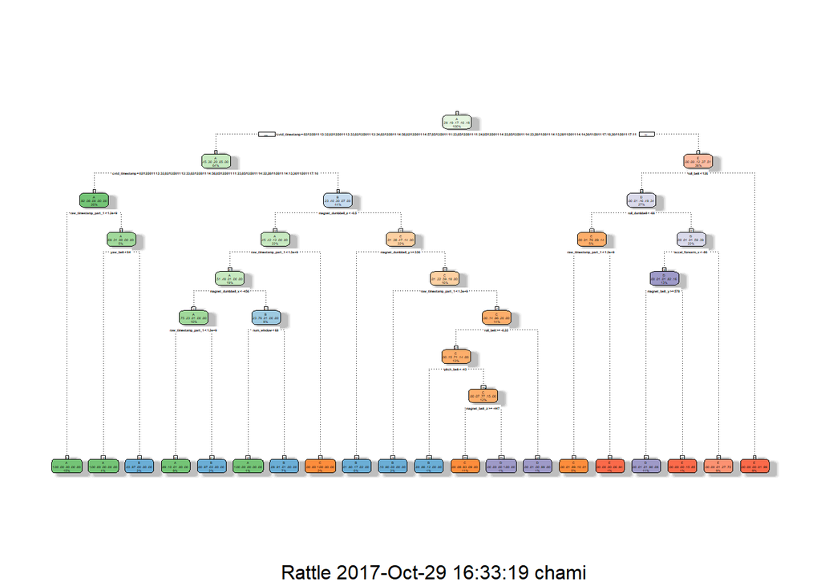

```r
fancyRpartPlot(mod3)
```

#### Final Model

```r
model <- c("rf","lda","rpart")
accuracy <- c(accuracy1,accuracy2,accuracy3)
data.frame(model,accuracy)
```

```
##   model  accuracy
## 1    rf 0.9989805
## 2   lda 0.8502974
## 3 rpart 0.9009346
```

#### Predicting Results

Predicting results for testing data

```r
set.seed(333)
pred <-predict(mod1, testing)
pred
```

```
##  2  3  4  5  6  7  8  9 10 11 12 13 14 15 16 17 18 19 20 21
##  B  A  B  A  A  E  D  B  A  A  B  C  B  A  E  E  A  B  B  B
## Levels: A B C D E
```

#### Write the results to a text file for submission

```r
pml_write_files = function(x){
    n = length(x)
    for(i in 1:n){
        filename = paste0("problem_id_",i,".txt")
        write.table(x[i],file=filename,quote=FALSE,row.names=FALSE,col.names=FALSE)
    }
}

pml_write_files(pred)
```